# Project: No-show Appointments Data Analysis

- Introduction
- Data Wrangling
- Exploratory Data Analysis
- Conclusions
- References

## Introduction

> Having a biomedical background and working for a pharmaceutical company, I am always very interested in the healthcare, so here I choose this dataset, no-show appointments (Reference 1) for my data analysis project.

> In this dataset, there are 110527 observations (a medical appointment per record) and 14 variables including 1 dependent variable, a patient shows up to his/her appointment or not, and 13 independent variables with patients' characteristics. The following table describles the variable names with their definition. For the variable, Scholarship, means whether a patient enrolls in Brasilian welfare program or not. For more details about the program, you can learn more in the reference 2.

| Variable Name | Definition |
| --- | --- |
| PatientId | Identification of a patient |
| AppointmentID | Identification of each appointment |
| Gender | M = Male; F = Female |
| ScheduledDay | The Date of patient set up their appointment. |
| AppointmentDay | The Date of the appointment |
| Age | The age of the patient |
| Neighbourhood | The location of the hospital |
| Scholarship | Indicates whether or not the patient was enrolled in Brasilian welfare program (Reference 2) |
| Hipertension | 0: non-hypertension 1: hypertension |
| Diabetes | 0: non-diabetes 1: diabetes |
| Alcoholism | 0: non-alcoholic 1: alcoholic |
| Handcap | 0: False 1: True |
| SMS_received | 0: did not send any message to the patient 1: 1 or more messages sent to the patient |
| No-show | 'Yes': the patient did not show up to their appointment ‘No’: the patient showed up. |

> Based on the above table, the question I am interested in is

**What are the characteristics that a patient who shows up for his/her scheduled appointment demonstrate?**

> I will perform a exploratory data analysis to answer this question. Before loading the dataset, I install the following libraries I will use in the project.

```python
# Install the libraries for this analysis
import numpy as np
import pandas as pd
import matplotlib.pyplot as plt
import seaborn as sns
from scipy import stats

%matplotlib inline
```

## Data Wrangling

### General Properties

> I load the No-show dataset into the Jupyter notebook and take a look at the first 5 rows to get a sense of the values for each variable and then I check the numbers of rows, columns, missing values and data types.

```python
# Load the dataset
df = pd.read_csv('noshowappointments-kagglev2-may-2016.csv')
```

```python
# Take a look at the first 5 rows
df.head()
```

|  | PatientId | AppointmentID | Gender | ScheduledDay | AppointmentDay | Age | Neighbourhood | Scholarship | Hipertension | Diabetes | Alcoholism | Handcap | SMS_received | No-show |
| --- | --- | --- | --- | --- | --- | --- | --- | --- | --- | --- | --- | --- | --- | --- |
| 0 | 2.987250e+13 | 5642903 | F | 2016-04-29T18:38:08Z | 2016-04-29T00:00:00Z | 62 | JARDIM DA PENHA | 0 | 1 | 0 | 0 | 0 | 0 | No |
| 1 | 5.589978e+14 | 5642503 | M | 2016-04-29T16:08:27Z | 2016-04-29T00:00:00Z | 56 | JARDIM DA PENHA | 0 | 0 | 0 | 0 | 0 | 0 | No |
| 2 | 4.262962e+12 | 5642549 | F | 2016-04-29T16:19:04Z | 2016-04-29T00:00:00Z | 62 | MATA DA PRAIA | 0 | 0 | 0 | 0 | 0 | 0 | No |
| 3 | 8.679512e+11 | 5642828 | F | 2016-04-29T17:29:31Z | 2016-04-29T00:00:00Z | 8 | PONTAL DE CAMBURI | 0 | 0 | 0 | 0 | 0 | 0 | No |
| 4 | 8.841186e+12 | 5642494 | F | 2016-04-29T16:07:23Z | 2016-04-29T00:00:00Z | 56 | JARDIM DA PENHA | 0 | 1 | 1 | 0 | 0 | 0 | No |

```python
# Find the numbers of rows and columns
df.shape
```

```
(110527, 14)
```

```python
# Find data types and missing values in each column
df.info()
```

```
<class 'pandas.core.frame.DataFrame'>
RangeIndex: 110527 entries, 0 to 110526
Data columns (total 14 columns):
PatientId         110527 non-null float64
AppointmentID     110527 non-null int64
Gender            110527 non-null object
ScheduledDay      110527 non-null object
AppointmentDay    110527 non-null object
Age               110527 non-null int64
Neighbourhood     110527 non-null object
Scholarship       110527 non-null int64
Hipertension      110527 non-null int64
Diabetes          110527 non-null int64
Alcoholism        110527 non-null int64
Handcap           110527 non-null int64
SMS_received      110527 non-null int64
No-show           110527 non-null object
dtypes: float64(1), int64(8), object(5)
memory usage: 11.8+ MB
```

```python
# Find missing values in each column
df.isnull().sum()
```

```
PatientId         0
AppointmentID     0
Gender            0
ScheduledDay      0
AppointmentDay    0
Age               0
Neighbourhood     0
Scholarship       0
Hipertension      0
Diabetes          0
Alcoholism        0
Handcap           0
SMS_received      0
No-show           0
dtype: int64
```

```python
# Find distributions for continuous variables, Age
df.describe()
```

|  | PatientId | AppointmentID | Age | Scholarship | Hipertension | Diabetes | Alcoholism | Handcap | SMS_received |
| --- | --- | --- | --- | --- | --- | --- | --- | --- | --- |
| count | 1.105270e+05 | 1.105270e+05 | 110527.000000 | 110527.000000 | 110527.000000 | 110527.000000 | 110527.000000 | 110527.000000 | 110527.000000 |
| mean | 1.474963e+14 | 5.675305e+06 | 37.088874 | 0.098266 | 0.197246 | 0.071865 | 0.030400 | 0.022248 | 0.321026 |
| std | 2.560949e+14 | 7.129575e+04 | 23.110205 | 0.297675 | 0.397921 | 0.258265 | 0.171686 | 0.161543 | 0.466873 |
| min | 3.921784e+04 | 5.030230e+06 | -1.000000 | 0.000000 | 0.000000 | 0.000000 | 0.000000 | 0.000000 | 0.000000 |
| 25% | 4.172614e+12 | 5.640286e+06 | 18.000000 | 0.000000 | 0.000000 | 0.000000 | 0.000000 | 0.000000 | 0.000000 |
| 50% | 3.173184e+13 | 5.680573e+06 | 37.000000 | 0.000000 | 0.000000 | 0.000000 | 0.000000 | 0.000000 | 0.000000 |
| 75% | 9.439172e+13 | 5.725524e+06 | 55.000000 | 0.000000 | 0.000000 | 0.000000 | 0.000000 | 0.000000 | 1.000000 |
| max | 9.999816e+14 | 5.790484e+06 | 115.000000 | 1.000000 | 1.000000 | 1.000000 | 1.000000 | 4.000000 | 1.000000 |

> Luckily, there is no missing values in each column. The data type of ScheduledDay and AppointmentDay are all string. I will convert them to the dates in the next session. In the describe table, the minimum value of Age is -1 which does not make any senses. I will check how many rows with this value and see if I need to remove them from the dataset. Also, I found that the maximum value of Handcap is 4, but in the defintion, the values are True (1) or False (0). I am curious what other values that this variable has.

```python
# Check the values for Handcap
df['Handcap'].value_counts()
```

```
0    108286
1      2042
2       183
3        13
4         3
Name: Handcap, dtype: int64
```

> There are 5 groups in this variable and I am not sure about what this means, so I will exclude this variable from this analysis.

### Data Cleaning

> After checking the properties in the previous session, in this session, I would like to clean the dataset and prepare for exploratory data analysis. First, I convert ScheduledDay and AppointmentDay from string to time format, and label them into the weekdays. Second, the minimum of age is -1 which does not make any senses. I will find how many age is equal to -1 and if not much, I treat them as outliers (error) and delete them from the dataset.

```python
# 1.1 Convert ScheduledDay from string to time format and label to weekdays
df['ScheduledDay'] = pd.to_datetime(df['ScheduledDay'])
df['Sched_Week'] = df['ScheduledDay'].apply(lambda x:x.weekday())
dmap = {0:'Mon',1:'Tue',2:'Wed',3:'Thu',4:'Fri',5:'Sat',6:'Sun'}
df['Sched_Weekf'] = df['Sched_Week'].map(dmap)
```

```python
# 1.2 Convert AppointmentDay from strings to time format and label to weekdays
df['AppointmentDay'] = pd.to_datetime(df['AppointmentDay'])
df['App_Week'] = df['AppointmentDay'].apply(lambda x:x.weekday())
df['App_Weekf'] = df['App_Week'].map(dmap)
```

```python
# Confirm the conversion
df.info()
```

```
<class 'pandas.core.frame.DataFrame'>
RangeIndex: 110527 entries, 0 to 110526
Data columns (total 18 columns):
PatientId         110527 non-null float64
AppointmentID     110527 non-null int64
Gender            110527 non-null object
ScheduledDay      110527 non-null datetime64[ns]
AppointmentDay    110527 non-null datetime64[ns]
Age               110527 non-null int64
Neighbourhood     110527 non-null object
Scholarship       110527 non-null int64
Hipertension      110527 non-null int64
Diabetes          110527 non-null int64
Alcoholism        110527 non-null int64
Handcap           110527 non-null int64
SMS_received      110527 non-null int64
No-show           110527 non-null object
Sched_Week        110527 non-null int64
Sched_Weekf       110527 non-null object
App_Week          110527 non-null int64
App_Weekf         110527 non-null object
dtypes: datetime64[ns](2), float64(1), int64(10), object(5)
memory usage: 15.2+ MB
```

```python
# 2. Find Age = -1 and how many of it
df.query('Age == -1').Age.value_counts()
```

```
-1    1
Name: Age, dtype: int64
```

```python
# Remove Age = -1 from the dataset and check the change in the number of observations
df2 = df.query('Age >= 0')
df2.shape
```

```
(110526, 18)
```

```python
# 3. Remove Handcap
df2 = df2.drop(['Handcap'], axis=1)
```

```python
df2.head()
```

|  | PatientId | AppointmentID | Gender | ScheduledDay | AppointmentDay | Age | Neighbourhood | Scholarship | Hipertension | Diabetes | Alcoholism | SMS_received | No-show | Sched_Week | Sched_Weekf | App_Week | App_Weekf |
| --- | --- | --- | --- | --- | --- | --- | --- | --- | --- | --- | --- | --- | --- | --- | --- | --- | --- |
| 0 | 2.987250e+13 | 5642903 | F | 2016-04-29 18:38:08 | 2016-04-29 | 62 | JARDIM DA PENHA | 0 | 1 | 0 | 0 | 0 | No | 4 | Fri | 4 | Fri |
| 1 | 5.589978e+14 | 5642503 | M | 2016-04-29 16:08:27 | 2016-04-29 | 56 | JARDIM DA PENHA | 0 | 0 | 0 | 0 | 0 | No | 4 | Fri | 4 | Fri |
| 2 | 4.262962e+12 | 5642549 | F | 2016-04-29 16:19:04 | 2016-04-29 | 62 | MATA DA PRAIA | 0 | 0 | 0 | 0 | 0 | No | 4 | Fri | 4 | Fri |
| 3 | 8.679512e+11 | 5642828 | F | 2016-04-29 17:29:31 | 2016-04-29 | 8 | PONTAL DE CAMBURI | 0 | 0 | 0 | 0 | 0 | No | 4 | Fri | 4 | Fri |
| 4 | 8.841186e+12 | 5642494 | F | 2016-04-29 16:07:23 | 2016-04-29 | 56 | JARDIM DA PENHA | 0 | 1 | 1 | 0 | 0 | No | 4 | Fri | 4 | Fri |

> After finishing above 3 steps, the dataset is ready for exploratory data analysis.

## Exploratory Data Analysis

> Here, I relist the question I asked in the introduction session.

### What are the characteristics that a patient who shows up for his/her scheduled appointment demonstrate?

#### 1. Analyze binomial variable by using 2 * 2 table method

> I would like to take a look at binomial variables. There are 6 binomial variables in this dataset: Gender, Scholarship, Hipertension, Diabetes, Alcoholism, and SMS_received. I will perform the same method to these variables. First, I find the count and proportion in each group of a binomial variable and no-show, create a 2 *2 table, and calculate raletive risk and odds ratio. There is a article about interpreting the result in 2*2 groups (Reference 3).

> Here, I am using Gender * No-Show as an example:

| Gender/App | No-Show (Yes) | Show (No) | Tot 2 |
| --- | --- | --- | --- |
| Female | a | b | a+b |
| Male | c | d | c+d |
| Tot 1 | a+c | b+d | n |

> Definitions: Risk describes the probability of No show  
> P0 = probability of No-show (Yes) for males  
> P1 = probability of No-show (Yes) for females  
> P0 = c / (c + d)  
> P1 = a / (a + b)  
> Risk difference: RD = P1 – P0

> Relative risk: RR = P1/P0  
> O0 = odds for males: O0= P0/(1 – P0)  
> O1 = odds for females: O1= P1/(1 – P1)  
> OR = odds ratio = O1 / O0 = (P1 / [1 – P1]) / P0 / [1 – P0]) = (a x d) / (b x c)  
> If (a + c)/n is “small,” RR and OR have similar values.

> A relative risk of 1 (RR = 1) means that females and males have the same risk of No-show. If RR is greater than 1, this means that female have a higher risk than males.  
> If RR = 1.5, this means that the risk of females is 50% greater than that of males.  
> If RR = 2, this means that the risk is doubled.  
> If RR = 0.5, this means that females only have half the risk of males. This can also be referred to as a “protective factor.” It is important to bear in mind which groups are used as reference.  
> Odds ratio (OR) is used as a measure of association. The odds ratio is the quotient of the chances (odds) of a disease (cure) for persons with or without exposure (therapy). Here, it's no-show for females or males.

##### a. Gender by No-Show

> From the count, apparently, the number of females is way more than the number of males, so I calculate the No-show and show percentages in females and males separately.

```python
# The count in each group of gender and no-show
df2.groupby('No-show')['Gender'].value_counts()
```

```
No-show  Gender
No       F         57245
         M         30962
Yes      F         14594
         M          7725
Name: Gender, dtype: int64
```

```python
# Create a 2*2 table to see the percentage in each group
# Note: denominators are calculated by each gender group
sex_app_tb = pd.crosstab(df2['Gender'], df2['No-show']).apply(lambda r: r/r.sum(), axis=1)
sex_app_tb
```

| No-show Gender | No | Yes |
| --- | --- | --- |
| F | 0.796851 | 0.203149 |
| M | 0.800321 | 0.199679 |

```python
# Calculate Relative Risk
RR = sex_app_tb['Yes']['F']/sex_app_tb['Yes']['M']
RR
```

```
1.017373986806438
```

```python
# Odds for males and females
sex_app_tb['Odds'] = sex_app_tb['Yes'] * (1-sex_app_tb['Yes'])
```

```python
sex_app_tb
```

| No-show Gender | No | Yes | Odds |
| --- | --- | --- | --- |
| F | 0.796851 | 0.203149 | 0.161879 |
| M | 0.800321 | 0.199679 | 0.159808 |

```python
# Odds ratio
ORR = sex_app_tb['Odds']['F']/sex_app_tb['Odds']['M']
ORR
```

```
1.0129638750184298
```

##### b. Scholarship by No-show

> Based on the count of scholarship, the number of patients who enroll in the program is less than the number of patients who do not. Then I calculate the percentage.

```python
# The count in each group of Scholarship and no-show
df2.groupby('No-show')['Scholarship'].value_counts()
```

```
No-show  Scholarship
No       0              79924
         1               8283
Yes      0              19741
         1               2578
Name: Scholarship, dtype: int64
```

```python
# Create a 2*2 table to see the percentage in each group
# Note: denominators are calculated by each Scholarship group
sch_app_tb = pd.crosstab(df2['Scholarship'], df2['No-show']).apply(lambda r: r/r.sum(), axis=1)
sch_app_tb
```

| No-show Scholarship | No | Yes |
| --- | --- | --- |
| 0 | 0.801926 | 0.198074 |
| 1 | 0.762637 | 0.237363 |

```python
# Calculate Relative Risk
sch_RR = sch_app_tb['Yes'][1]/sch_app_tb['Yes'][0]
sch_RR
```

```
1.198358117046747
```

```python
# Odds for enroll scholarship and non enroll scholarship
sch_app_tb['Odds'] = sch_app_tb['Yes'] * (1-sch_app_tb['Yes'])
sch_app_tb
```

| No-show Scholarship | No | Yes | Odds |
| --- | --- | --- | --- |
| 0 | 0.801926 | 0.198074 | 0.158840 |
| 1 | 0.762637 | 0.237363 | 0.181022 |

```python
# Odds ratio
sch_ORR = sch_app_tb['Odds'][1]/sch_app_tb['Odds'][0]
sch_ORR
```

```
1.1396458924151784
```

##### c. Hipertension

> From the counts, the number of hypertension patients is less than the number of non-hypertension patients.

```python
# The count in each group of Hipertension and no-show
df2.groupby('No-show')['Hipertension'].value_counts()
```

```
No-show  Hipertension
No       0               70178
         1               18029
Yes      0               18547
         1                3772
Name: Hipertension, dtype: int64
```

```python
# Create a 2*2 table to see the percentage in each group
# Note: denominators are calculated by each Hipertension group
hi_app_tb = pd.crosstab(df2['Hipertension'], df2['No-show']).apply(lambda r: r/r.sum(), axis=1)
hi_app_tb
```

| No-show Hipertension | No | Yes |
| --- | --- | --- |
| 0 | 0.790961 | 0.209039 |
| 1 | 0.826980 | 0.173020 |

```python
# Calculate Relative Risk
hi_RR = hi_app_tb['Yes'][1]/hi_app_tb['Yes'][0]
hi_RR
```

```
0.8276898037794616
```

```python
# Odds for with hipertension and without hipertension
hi_app_tb['Odds'] = hi_app_tb['Yes'] * (1-hi_app_tb['Yes'])
hi_app_tb
```

| No-show Hipertension | No | Yes | Odds |
| --- | --- | --- | --- |
| 0 | 0.790961 | 0.209039 | 0.165342 |
| 1 | 0.826980 | 0.173020 | 0.143084 |

```python
# Calculate Odds ratio
hi_ORR = hi_app_tb['Odds'][1]/hi_app_tb['Odds'][0]
hi_ORR
```

```
0.8653819847005272
```

##### d. Diabetes

> From the counts, the number of diabetes patients is less than the number of non-diabetes patients.

```python
# The count in each group of Diabetes and no-show
df2.groupby('No-show')['Diabetes'].value_counts()
```

```
No-show  Diabetes
No       0           81694
         1            6513
Yes      0           20889
         1            1430
Name: Diabetes, dtype: int64
```

```python
# Create a 2*2 table to see the percentage in each group
# Note: denominators are calculated by each Diabetes group
di_app_tb = pd.crosstab(df2['Diabetes'], df2['No-show']).apply(lambda r: r/r.sum(), axis=1)
di_app_tb
```

| No-show Diabetes | No | Yes |
| --- | --- | --- |
| 0 | 0.796370 | 0.203630 |
| 1 | 0.819967 | 0.180033 |

```python
# Calculate Relative Risk
di_RR = di_app_tb['Yes'][1]/di_app_tb['Yes'][0]
di_RR
```

```
0.8841159400804455
```

```python
# Odds for with diabetes and without diabetes
di_app_tb['Odds'] = di_app_tb['Yes'] * (1-di_app_tb['Yes'])
di_app_tb
```

| No-show Diabetes | No | Yes | Odds |
| --- | --- | --- | --- |
| 0 | 0.796370 | 0.203630 | 0.162165 |
| 1 | 0.819967 | 0.180033 | 0.147621 |

```python
# Calculate Odds ratio
di_ORR = di_app_tb['Odds'][1]/di_app_tb['Odds'][0]
di_ORR
```

```
0.9103134740150118
```

##### e. Alcoholism

> From the counts, the number of alcoholic patients is less than the number of non-alcoholic patients.

```python
# The count in each group of Alcoholism and no-show
df2.groupby('No-show')['Alcoholism'].value_counts()
```

```
No-show  Alcoholism
No       0             85524
         1              2683
Yes      0             21642
         1               677
Name: Alcoholism, dtype: int64
```

```python
# Create a 2*2 table to see the percentage in each group
# Note: denominators are calculated by each Alcoholism group
al_app_tb = pd.crosstab(df2['Alcoholism'], df2['No-show']).apply(lambda r: r/r.sum(), axis=1)
al_app_tb
```

| No-show Alcoholism | No | Yes |
| --- | --- | --- |
| 0 | 0.798052 | 0.201948 |
| 1 | 0.798512 | 0.201488 |

```python
# Calculate Relative Risk
al_RR = al_app_tb['Yes'][1]/al_app_tb['Yes'][0]
al_RR
```

```
0.9977207843214912
```

```python
# Odds for with Alcoholism and without Alcoholism
al_app_tb['Odds'] = al_app_tb['Yes'] * (1-al_app_tb['Yes'])
al_app_tb
```

| No-show Alcoholism | No | Yes | Odds |
| --- | --- | --- | --- |
| 0 | 0.798052 | 0.201948 | 0.161165 |
| 1 | 0.798512 | 0.201488 | 0.160891 |

```python
# Calculate Odds ratio
al_ORR = al_app_tb['Odds'][1]/al_app_tb['Odds'][0]
al_ORR
```

```
0.9982962293349484
```

##### f. SMS_received

> From the counts, the number of patients who received SMS is less than the number of patients who do not.

```python
# # The count in each group of SMS_received and no-show
df2.groupby('No-show')['SMS_received'].value_counts()
```

```
No-show  SMS_received
No       0               62509
         1               25698
Yes      0               12535
         1                9784
Name: SMS_received, dtype: int64
```

```python
# Create a 2*2 table to see the percentage in each group
# Note: denominators are calculated by each SMS_received group
sms_app_tb = pd.crosstab(df2['SMS_received'], df2['No-show']).apply(lambda r: r/r.sum(), axis=1)
sms_app_tb
```

| No-show SMS_received | No | Yes |
| --- | --- | --- |
| 0 | 0.832965 | 0.167035 |
| 1 | 0.724255 | 0.275745 |

```python
# Calculate Relative Risk
sms_RR = sms_app_tb['Yes'][1]/sms_app_tb['Yes'][0]
sms_RR
```

```
1.6508210155131384
```

```python
# Odds for with SMS_received and without SMS_received
sms_app_tb['Odds'] = sms_app_tb['Yes'] * (1-sms_app_tb['Yes'])
sms_app_tb
```

| No-show SMS_received | No | Yes | Odds |
| --- | --- | --- | --- |
| 0 | 0.832965 | 0.167035 | 0.139135 |
| 1 | 0.724255 | 0.275745 | 0.199710 |

```python
# Calculate Odds ratio
sms_ORR = sms_app_tb['Odds'][1]/sms_app_tb['Odds'][0]
sms_ORR
```

```
1.4353725802930137
```

#### 2. Aanlyze categorical nomial variables

> Then I would like to take a look at ScheduledDay, AppointmentDay, and Neighnourhood. I already derived the weekdays from ScheduledDay and AppointmentDay separately because I am interested in if a patient shows up to the weekend's or weekday's appointment and if the day that a patient makes an appointment that will influences show-up rate or not. Also, I want to know which hospital has a lowerest or highest attandance rate.

##### a. AppointmentDay (derived weekday variable: App_weekf)

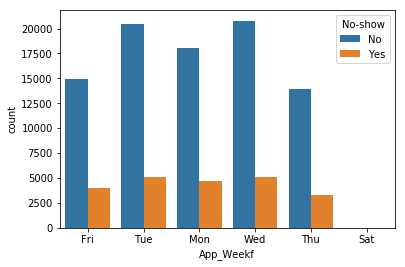

```python
# Appointment Day: Apparently, the number of patients who show up to appointments is way higher than
# the number of patients who did not show up. Also, the number on Saturday is too little, so cannot be visualized
# in the plot. Thus, calculating proportions is more reasonable.
sns.countplot(x='App_Weekf', hue='No-show', data=df2);
```

```python
# By calculation proportions, we can find that the less people show up to appointments on Saturday.
app_tb = pd.crosstab(df2['App_Weekf'],df2['No-show']).apply(lambda r: r/r.sum(), axis=1)
app_tb
```

| No-show App_Weekf | No | Yes |
| --- | --- | --- |
| Fri | 0.787739 | 0.212261 |
| Mon | 0.793519 | 0.206481 |
| Sat | 0.769231 | 0.230769 |
| Thu | 0.806459 | 0.193541 |
| Tue | 0.799064 | 0.200936 |
| Wed | 0.803108 | 0.196892 |

##### b. ScheduledDay (Sched_weekf)

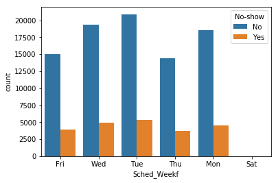

```python
# Do the same thing for ScheduledDay. The number of Saturday is too little so cannot be visualized in the plot.
sns.countplot(x='Sched_Weekf', hue='No-show', data=df2);
```

```python
# By calculation proportions, we can patients who make appointments on Saturday have the highest attendance rate.
sch_tb = pd.crosstab(df2['Sched_Weekf'],df2['No-show']).apply(lambda r: r/r.sum(), axis=1)
sch_tb
```

| No-show Sched_Weekf | No | Yes |
| --- | --- | --- |
| Fri | 0.794502 | 0.205498 |
| Mon | 0.802417 | 0.197583 |
| Sat | 0.958333 | 0.041667 |
| Thu | 0.795275 | 0.204725 |
| Tue | 0.797806 | 0.202194 |
| Wed | 0.798904 | 0.201096 |

##### c. Neighbourhood

```python
# Find the numbers of No-show and Show in each hospital (Neighbourhood)
ctnei = pd.crosstab(df2['Neighbourhood'],df2['No-show']).apply(lambda r: r, axis=1)
ctnei.reset_index(level=0, inplace=True)
ctnei
```

| No-show | Neighbourhood | No | Yes |
| --- | --- | --- | --- |
| 0 | AEROPORTO | 7 | 1 |
| 1 | ANDORINHAS | 1741 | 521 |
| 2 | ANTÔNIO HONÓRIO | 221 | 50 |
| 3 | ARIOVALDO FAVALESSA | 220 | 62 |
| 4 | BARRO VERMELHO | 332 | 91 |
| 5 | BELA VISTA | 1523 | 384 |
| 6 | BENTO FERREIRA | 665 | 193 |
| 7 | BOA VISTA | 254 | 58 |
| 8 | BONFIM | 2223 | 550 |
| 9 | CARATOÍRA | 1974 | 591 |
| 10 | CENTRO | 2631 | 703 |
| 11 | COMDUSA | 254 | 56 |
| 12 | CONQUISTA | 689 | 160 |
| 13 | CONSOLAÇÃO | 1139 | 237 |
| 14 | CRUZAMENTO | 1094 | 304 |
| 15 | DA PENHA | 1788 | 429 |
| 16 | DE LOURDES | 258 | 47 |
| 17 | DO CABRAL | 472 | 88 |
| 18 | DO MOSCOSO | 321 | 92 |
| 19 | DO QUADRO | 709 | 140 |
| 20 | ENSEADA DO SUÁ | 183 | 52 |
| 21 | ESTRELINHA | 432 | 106 |
| 22 | FONTE GRANDE | 533 | 149 |
| 23 | FORTE SÃO JOÃO | 1543 | 346 |
| 24 | FRADINHOS | 210 | 48 |
| 25 | GOIABEIRAS | 563 | 137 |
| 26 | GRANDE VITÓRIA | 854 | 217 |
| 27 | GURIGICA | 1562 | 456 |
| 28 | HORTO | 133 | 42 |
| 29 | ILHA DAS CAIEIRAS | 836 | 235 |
| ... | ... | ... | ... |
| 51 | PARQUE INDUSTRIAL | 1 | 0 |
| 52 | PARQUE MOSCOSO | 623 | 179 |
| 53 | PIEDADE | 364 | 88 |
| 54 | PONTAL DE CAMBURI | 57 | 12 |
| 55 | PRAIA DO CANTO | 845 | 190 |
| 56 | PRAIA DO SUÁ | 994 | 294 |
| 57 | REDENÇÃO | 1278 | 275 |
| 58 | REPÚBLICA | 692 | 143 |
| 59 | RESISTÊNCIA | 3525 | 906 |
| 60 | ROMÃO | 1740 | 474 |
| 61 | SANTA CECÍLIA | 325 | 123 |
| 62 | SANTA CLARA | 372 | 134 |
| 63 | SANTA HELENA | 141 | 37 |
| 64 | SANTA LUÍZA | 351 | 77 |
| 65 | SANTA LÚCIA | 352 | 86 |
| 66 | SANTA MARTHA | 2635 | 496 |
| 67 | SANTA TEREZA | 1060 | 272 |
| 68 | SANTO ANDRÉ | 2063 | 508 |
| 69 | SANTO ANTÔNIO | 2262 | 484 |
| 70 | SANTOS DUMONT | 907 | 369 |
| 71 | SANTOS REIS | 435 | 112 |
| 72 | SEGURANÇA DO LAR | 117 | 28 |
| 73 | SOLON BORGES | 400 | 69 |
| 74 | SÃO BENEDITO | 1152 | 287 |
| 75 | SÃO CRISTÓVÃO | 1473 | 363 |
| 76 | SÃO JOSÉ | 1549 | 428 |
| 77 | SÃO PEDRO | 1933 | 515 |
| 78 | TABUAZEIRO | 2559 | 573 |
| 79 | UNIVERSITÁRIO | 120 | 32 |
| 80 | VILA RUBIM | 710 | 141 |

81 rows × 3 columns

```python
# There are 81 hospitals in this dataset and find out the percentages of No-show and show in each hospital
nei_tb = pd.crosstab(df2['Neighbourhood'],df2['No-show']).apply(lambda r: r/r.sum(), axis=1)
nei_tb.reset_index(level=0, inplace=True)
nei_tb
```

| No-show | Neighbourhood | No | Yes |
| --- | --- | --- | --- |
| 0 | AEROPORTO | 0.875000 | 0.125000 |
| 1 | ANDORINHAS | 0.769673 | 0.230327 |
| 2 | ANTÔNIO HONÓRIO | 0.815498 | 0.184502 |
| 3 | ARIOVALDO FAVALESSA | 0.780142 | 0.219858 |
| 4 | BARRO VERMELHO | 0.784870 | 0.215130 |
| 5 | BELA VISTA | 0.798637 | 0.201363 |
| 6 | BENTO FERREIRA | 0.775058 | 0.224942 |
| 7 | BOA VISTA | 0.814103 | 0.185897 |
| 8 | BONFIM | 0.801659 | 0.198341 |
| 9 | CARATOÍRA | 0.769591 | 0.230409 |
| 10 | CENTRO | 0.789142 | 0.210858 |
| 11 | COMDUSA | 0.819355 | 0.180645 |
| 12 | CONQUISTA | 0.811543 | 0.188457 |
| 13 | CONSOLAÇÃO | 0.827762 | 0.172238 |
| 14 | CRUZAMENTO | 0.782546 | 0.217454 |
| 15 | DA PENHA | 0.806495 | 0.193505 |
| 16 | DE LOURDES | 0.845902 | 0.154098 |
| 17 | DO CABRAL | 0.842857 | 0.157143 |
| 18 | DO MOSCOSO | 0.777240 | 0.222760 |
| 19 | DO QUADRO | 0.835100 | 0.164900 |
| 20 | ENSEADA DO SUÁ | 0.778723 | 0.221277 |
| 21 | ESTRELINHA | 0.802974 | 0.197026 |
| 22 | FONTE GRANDE | 0.781525 | 0.218475 |
| 23 | FORTE SÃO JOÃO | 0.816834 | 0.183166 |
| 24 | FRADINHOS | 0.813953 | 0.186047 |
| 25 | GOIABEIRAS | 0.804286 | 0.195714 |
| 26 | GRANDE VITÓRIA | 0.797386 | 0.202614 |
| 27 | GURIGICA | 0.774034 | 0.225966 |
| 28 | HORTO | 0.760000 | 0.240000 |
| 29 | ILHA DAS CAIEIRAS | 0.780579 | 0.219421 |
| ... | ... | ... | ... |
| 51 | PARQUE INDUSTRIAL | 1.000000 | 0.000000 |
| 52 | PARQUE MOSCOSO | 0.776808 | 0.223192 |
| 53 | PIEDADE | 0.805310 | 0.194690 |
| 54 | PONTAL DE CAMBURI | 0.826087 | 0.173913 |
| 55 | PRAIA DO CANTO | 0.816425 | 0.183575 |
| 56 | PRAIA DO SUÁ | 0.771739 | 0.228261 |
| 57 | REDENÇÃO | 0.822923 | 0.177077 |
| 58 | REPÚBLICA | 0.828743 | 0.171257 |
| 59 | RESISTÊNCIA | 0.795531 | 0.204469 |
| 60 | ROMÃO | 0.785908 | 0.214092 |
| 61 | SANTA CECÍLIA | 0.725446 | 0.274554 |
| 62 | SANTA CLARA | 0.735178 | 0.264822 |
| 63 | SANTA HELENA | 0.792135 | 0.207865 |
| 64 | SANTA LUÍZA | 0.820093 | 0.179907 |
| 65 | SANTA LÚCIA | 0.803653 | 0.196347 |
| 66 | SANTA MARTHA | 0.841584 | 0.158416 |
| 67 | SANTA TEREZA | 0.795796 | 0.204204 |
| 68 | SANTO ANDRÉ | 0.802412 | 0.197588 |
| 69 | SANTO ANTÔNIO | 0.823744 | 0.176256 |
| 70 | SANTOS DUMONT | 0.710815 | 0.289185 |
| 71 | SANTOS REIS | 0.795247 | 0.204753 |
| 72 | SEGURANÇA DO LAR | 0.806897 | 0.193103 |
| 73 | SOLON BORGES | 0.852878 | 0.147122 |
| 74 | SÃO BENEDITO | 0.800556 | 0.199444 |
| 75 | SÃO CRISTÓVÃO | 0.802288 | 0.197712 |
| 76 | SÃO JOSÉ | 0.783510 | 0.216490 |
| 77 | SÃO PEDRO | 0.789624 | 0.210376 |
| 78 | TABUAZEIRO | 0.817050 | 0.182950 |
| 79 | UNIVERSITÁRIO | 0.789474 | 0.210526 |
| 80 | VILA RUBIM | 0.834313 | 0.165687 |

81 rows × 3 columns

```python
# Find out the distribution of no-show and show rate
nei_tb.describe()
```

| No-show | No | Yes |
| --- | --- | --- |
| count | 81.000000 | 81.000000 |
| mean | 0.794572 | 0.205428 |
| std | 0.097230 | 0.097230 |
| min | 0.000000 | 0.000000 |
| 25% | 0.782546 | 0.179907 |
| 50% | 0.802412 | 0.197588 |
| 75% | 0.820093 | 0.217454 |
| max | 1.000000 | 1.000000 |

```python
# Find out the top 5 Show hospital
nei_tb.sort_values(by='No', ascending=False).head(5)
```

| No-show | Neighbourhood | No | Yes |
| --- | --- | --- | --- |
| 51 | PARQUE INDUSTRIAL | 1.000000 | 0.000000 |
| 31 | ILHA DO BOI | 0.914286 | 0.085714 |
| 0 | AEROPORTO | 0.875000 | 0.125000 |
| 48 | MÁRIO CYPRESTE | 0.854447 | 0.145553 |
| 73 | SOLON BORGES | 0.852878 | 0.147122 |

```python
# Take a look at the counts in top 5 hospital
# Only 1 record, the sample size is too little.
ctnei.query('Neighbourhood == "PARQUE INDUSTRIAL"')
```

| No-show | Neighbourhood | No | Yes |
| --- | --- | --- | --- |
| 51 | PARQUE INDUSTRIAL | 1 | 0 |

```python
ctnei.query('Neighbourhood == "ILHA DO BOI"')
```

| No-show | Neighbourhood | No | Yes |
| --- | --- | --- | --- |
| 31 | ILHA DO BOI | 32 | 3 |

```python
ctnei.query('Neighbourhood == "AEROPORTO"')
```

| No-show | Neighbourhood | No | Yes |
| --- | --- | --- | --- |
| 0 | AEROPORTO | 7 | 1 |

```python
ctnei.query('Neighbourhood == "MÁRIO CYPRESTE"')
```

| No-show | Neighbourhood | No | Yes |
| --- | --- | --- | --- |
| 48 | MÁRIO CYPRESTE | 317 | 54 |

> Based on the above calculation, the sample size of top 5 show hospital actually is very small. I am thinking about what is the more reasonable sample size for each hospital. Because we have 110527 records in this dataset, I use 1000 records (1%) as a threshold.

```python
ctnei['Hos_sumpt'] = ctnei['No'] + ctnei['Yes']
ctnei.head()
```

| No-show | Neighbourhood | No | Yes | Hos_sumpt |
| --- | --- | --- | --- | --- |
| 0 | AEROPORTO | 7 | 1 | 8 |
| 1 | ANDORINHAS | 1741 | 521 | 2262 |
| 2 | ANTÔNIO HONÓRIO | 221 | 50 | 271 |
| 3 | ARIOVALDO FAVALESSA | 220 | 62 | 282 |
| 4 | BARRO VERMELHO | 332 | 91 | 423 |

```python
# Keep the hospital with over 1000 appointments
ctnei_adj = ctnei.query('Hos_sumpt > 1000')
ctnei_adj.head()
```

| No-show | Neighbourhood | No | Yes | Hos_sumpt |
| --- | --- | --- | --- | --- |
| 1 | ANDORINHAS | 1741 | 521 | 2262 |
| 5 | BELA VISTA | 1523 | 384 | 1907 |
| 8 | BONFIM | 2223 | 550 | 2773 |
| 9 | CARATOÍRA | 1974 | 591 | 2565 |
| 10 | CENTRO | 2631 | 703 | 3334 |

```python
# Only 39 hospitals have over 1000 appointment (around 1% of the records in the dataset)
ctnei_adj.shape
```

```
(39, 4)
```

```python
ctnei_adj.describe()
```

[output not shown]

```python
# Calculate No-show and show rate in these 39 hospitals
ctnei_adj['No_pct'] = ctnei_adj['No']/ctnei_adj['Hos_sumpt']
ctnei_adj['Yes_pct'] = ctnei_adj['Yes']/ctnei_adj['Hos_sumpt']
ctnei_adj.head()
```

| No-show | Neighbourhood | No | Yes | Hos_sumpt | No_pct | Yes_pct |
| --- | --- | --- | --- | --- | --- | --- |
| 1 | ANDORINHAS | 1741 | 521 | 2262 | 0.769673 | 0.230327 |
| 5 | BELA VISTA | 1523 | 384 | 1907 | 0.798637 | 0.201363 |
| 8 | BONFIM | 2223 | 550 | 2773 | 0.801659 | 0.198341 |
| 9 | CARATOÍRA | 1974 | 591 | 2565 | 0.769591 | 0.230409 |
| 10 | CENTRO | 2631 | 703 | 3334 | 0.789142 | 0.210858 |

```python
ctnei_adj.sort_values(by='Yes_pct', ascending=False).head(5)
```

| No-show | Neighbourhood | No | Yes | Hos_sumpt | No_pct | Yes_pct |
| --- | --- | --- | --- | --- | --- | --- |
| 70 | SANTOS DUMONT | 907 | 369 | 1276 | 0.710815 | 0.289185 |
| 36 | ITARARÉ | 2591 | 923 | 3514 | 0.737336 | 0.262664 |
| 40 | JESUS DE NAZARETH | 2157 | 696 | 2853 | 0.756046 | 0.243954 |
| 33 | ILHA DO PRÍNCIPE | 1734 | 532 | 2266 | 0.765225 | 0.234775 |
| 9 | CARATOÍRA | 1974 | 591 | 2565 | 0.769591 | 0.230409 |

```python
ctnei_adj.sort_values(by='No_pct', ascending=False).head(5)
```

| No-show | Neighbourhood | No | Yes | Hos_sumpt | No_pct | Yes_pct |
| --- | --- | --- | --- | --- | --- | --- |
| 66 | SANTA MARTHA | 2635 | 496 | 3131 | 0.841584 | 0.158416 |
| 39 | JARDIM DA PENHA | 3246 | 631 | 3877 | 0.837245 | 0.162755 |
| 13 | CONSOLAÇÃO | 1139 | 237 | 1376 | 0.827762 | 0.172238 |
| 69 | SANTO ANTÔNIO | 2262 | 484 | 2746 | 0.823744 | 0.176256 |
| 57 | REDENÇÃO | 1278 | 275 | 1553 | 0.822923 | 0.177077 |

> Keeping only the hospitals with more than 1000 appointments (1% of the rows in the dataset) and finding out the Top 5 No-Show and Show rates hospitals give us more reasonable outcome. Before doing so, the top 1 hospital has 100% Show rate and 0% No-Show rate. It is not really realistic in the real world.

#### 3. Analyze continuous variables

> I would like to take a look at Age distribution between No-Show and Show.

```python
# Find distributions in Age
df3.groupby('No-show')['Age'].describe()
```

| No-show | count | mean | std | min | 25% | 50% | 75% | max |
| --- | --- | --- | --- | --- | --- | --- | --- | --- |
| No | 88207.0 | 37.790504 | 23.338645 | 0.0 | 18.0 | 38.0 | 56.0 | 115.0 |
| Yes | 22319.0 | 34.317667 | 21.965941 | 0.0 | 16.0 | 33.0 | 51.0 | 115.0 |

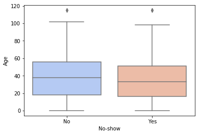

```python
# Draw a box plot of Age for No-show and show groups
sns.boxplot(x="No-show", y="Age",data=df3, palette="coolwarm");
```

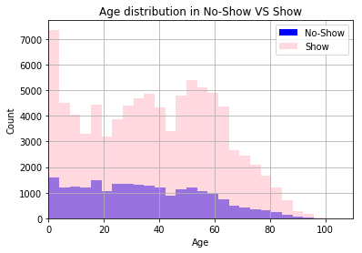

```python
# Draw a histogram to see the disrtibution of Age in No-Show and Show group
df2[df2['No-show'] == 'Yes']['Age'].hist(label='No-Show', bins=30, color='blue')
df2[df2['No-show'] == 'No']['Age'].hist(alpha=0.6, label='Show', bins=30, color='pink')
plt.xlabel('Age')
plt.ylabel('Count')
plt.title('Age distribution in No-Show VS Show')
plt.legend(loc=0)
plt.xlim(0,110);
```

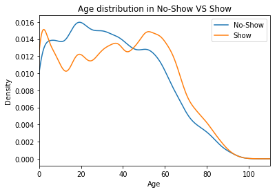

```python
# Draw a Density Plot to see the distribution of Age in No-Show and Show group
df2[df2['No-show'] == 'Yes']['Age'].plot.kde(label='No-Show')
df2[df2['No-show'] == 'No']['Age'].plot.kde(label='Show')
plt.xlabel('Age')
plt.ylabel('Density')
plt.title('Age distribution in No-Show VS Show')
plt.legend(loc=0)
plt.xlim(0,110);
```

> This distribution is not symmetric, more like right skewed, so it's better to use 5 summary numbers

```python
# The female's age distribution in No-Show and Show groups.
dff = df2.query('Gender == "F"')
dff.groupby('No-show')['Age'].describe()
```

| No-show | count | mean | std | min | 25% | 50% | 75% | max |
| --- | --- | --- | --- | --- | --- | --- | --- | --- |
| No | 57245.0 | 39.591126 | 22.342413 | 0.0 | 22.0 | 40.0 | 57.0 | 115.0 |
| Yes | 14594.0 | 36.162190 | 21.184209 | 0.0 | 20.0 | 34.0 | 52.0 | 115.0 |

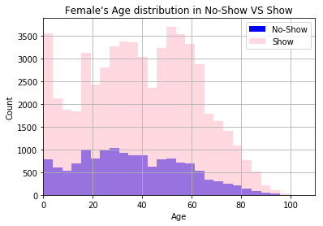

```python
# Draw a histogram for Female's Age in No-Show and Show groups
dff = df2.query('Gender == "F"')
dff[dff['No-show'] == 'Yes']['Age'].hist(label='No-Show', bins=30, color='blue')
dff[dff['No-show'] == 'No']['Age'].hist(alpha=0.6, label='Show', bins=30, color='pink')
plt.xlabel('Age')
plt.ylabel('Count')
plt.title("Female's Age distribution in No-Show VS Show")
plt.legend(loc=0)
plt.xlim(0,110);
```

```python
# The male's age distribution in No-Show and Show groups.
dff = df2.query('Gender == "M"')
dff.groupby('No-show')['Age'].describe()
```

| No-show | count | mean | std | min | 25% | 50% | 75% | max |
| --- | --- | --- | --- | --- | --- | --- | --- | --- |
| No | 30962.0 | 34.461372 | 24.734056 | 0.0 | 10.0 | 34.0 | 55.0 | 100.0 |
| Yes | 7725.0 | 30.833010 | 22.972200 | 0.0 | 10.0 | 28.0 | 49.0 | 97.0 |

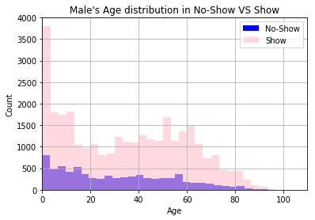

```python
# Draw a histogram for Male's Age in No-show and Show groups
dfm = df2.query('Gender == "M"')
dfm[dfm['No-show'] == 'Yes']['Age'].hist(label='No-Show', bins=30, color='blue')
dfm[dfm['No-show'] == 'No']['Age'].hist(alpha=0.6, label='Show', bins=30, color='pink')
plt.xlabel('Age')
plt.ylabel('Count')
plt.title("Male's Age distribution in No-Show VS Show")
plt.legend(loc=0)
plt.xlim(0,110);
```

## Conclusions

| Binomial Variable | Relative Risk | Odds Ratio |
| --- | --- | --- |
| Gender | 1.0174 | 1.013 |
| Scholarship | 1.1984 | 1.14 |
| Hipertension | 0.8277 | 0.8654 |
| Diabetes | 0.8841 | 0.9103 |
| Alcoholism | 0.9977 | 0.9983 |
| SMS_received | 1.6508 | 1.4354 |

1. By calculation proportions, the fewest patients show up to appointments on Saturday. However, patients who make appointments on Saturday have a highest showing-up rate.
2. Only 39 out of 81 hospitals have over 1000 appointments. (I think it is more fair to do the comparison when a hospital has more than a certain number of appointments. Here, I choose 1000 because this number is around 1% of sample size.) In these 39 hospitals, the highest showing up rate is 84.2% at SANTA MARTHA hospital and the highest no-showing rate is 28.9% at SANTOS DUMONT hospital.
3. Based on the Age distribution and 5 summary numbers, younger patients have a higher chance no-show than older patients. The age of "no-show" patients is 33 and the age of "show" patients is 38. If we only see females, the age of "No-show" patients is 34 and the age of "show" patients is 40. In males, the age of "No-show" patients is 28 and the age of "show" patients is 34. It looks like the age of "No-show" males is younger than the age of "No-show" females.

## Proposal for the next step

1. Subject level data: in this analysis, I only take a look at data based on appointment level data, so I woule like to take a look at subject level data. If a patient makes more appointments than other, he/she influences on the outcome more.
2. Different time periods: I would like to see a specific time period. For example, does patients show up to appointments in summer more than in winter?
3. Perform statistical models: for the binary outcome, No-show and Show, I would like to build up a logistic regression and see if I can find out more significant insights in the data.

## References

1. [Original source in Kaggle](https://www.kaggle.com/joniarroba/noshowappointments/home)
2. [Bolsa Família](https://en.wikipedia.org/wiki/Bolsa_Fam%C3%ADlia)
3. [Interpreting Results in 2 × 2 Tables](https://www.ncbi.nlm.nih.gov/pmc/articles/PMC2797398/)